# NOAA Storm Data Analysis

# Synopsis

The goal of this report is analyze the health effects and economic impacts of weather events on the population in the USA. Data from the NOAA Storm Database was used to generate the insights.

For the sampled period (1950 - 2011), Toronados caused the most fatalities and injuries and were also responsible for the most property damage. Excessive heat was the next greatest contributor to fatalities. Thunderstorm wind and flash flooding were also significant contributors to property damage. Further details are included in the report below.

# Data Processing

Data from the NOAA Storm Database is used to generate these insights:

```r
url <- "https://d396qusza40orc.cloudfront.net/repdata%2Fdata%2FStormData.csv.bz2"
destfile <- "download.csv"
storm_original <- read.csv("download.csv")
```

## Data Processing - Type of Events most harmful to public health

To understand what types of events are most harmful to public health, I’ll start by looking at the correlation of the following variables:

- Events (with beginning date)
- Fatalities
- Injuries

```r
library(dplyr)
```

```r
library(ggplot2)
sh <- select (storm_original, BGN_DATE, EVTYPE, FATALITIES, INJURIES)

#Converting date to correct format
library(lubridate)
sh$BGN_DATE <- mdy_hms(sh$BGN_DATE)
```

Next I want to compare the number of injuries that result from different event types, focusing on the top 10:

```r
sh1 <- sh %>%  # specify dataframe
        group_by(EVTYPE)   %>%
        summarize(i_sum = sum(INJURIES, na.rm = TRUE)) %>%
        arrange(desc(i_sum))

sh10 <- sh1[1:10, ]

sh10
```

```
## # A tibble: 10 x 2
##    EVTYPE            i_sum
##    <fct>             <dbl>
##  1 TORNADO           91346
##  2 TSTM WIND          6957
##  3 FLOOD              6789
##  4 EXCESSIVE HEAT     6525
##  5 LIGHTNING          5230
##  6 HEAT               2100
##  7 ICE STORM          1975
##  8 FLASH FLOOD        1777
##  9 THUNDERSTORM WIND  1488
## 10 HAIL               1361
```

Next I want to compare the number of fatalities that result from different event types, focusing on the top 10:

```r
shf <- sh %>%  # specify dataframe
        group_by(EVTYPE)   %>%
        summarize(f_sum = sum(FATALITIES, na.rm = TRUE)) %>%
        arrange(desc(f_sum))

sh10f <- shf[1:10, ]

sh10f
```

```
## # A tibble: 10 x 2
##    EVTYPE         f_sum
##    <fct>          <dbl>
##  1 TORNADO         5633
##  2 EXCESSIVE HEAT  1903
##  3 FLASH FLOOD      978
##  4 HEAT             937
##  5 LIGHTNING        816
##  6 TSTM WIND        504
##  7 FLOOD            470
##  8 RIP CURRENT      368
##  9 HIGH WIND        248
## 10 AVALANCHE        224
```

## Data Processing - Types of events with greatest economic consequences

To understand events with the greatest economic consequences we’ll compare events with economic indicators sugch as

- Events (with beginning date)
- Property Damage. Note: crop damage will not be looked at for this analysis

```r
se <- select (storm_original, BGN_DATE, EVTYPE, PROPDMG, CROPDMG)

#Converting date to correct format
se$BGN_DATE <- mdy_hms(se$BGN_DATE)
```

Finally I want to compare the economic impact of property damage resulting from different weather event types, focusing on the top 10:

```r
sep <- se %>%  # specify dataframe
        group_by(EVTYPE)   %>%
        summarize(p_sum = sum(PROPDMG, na.rm = TRUE)) %>%
        arrange(desc(p_sum))

sep10 <- sep[1:10, ]
sep10$p_sum <- sep10$p_sum/1000000

sep10
```

```
## # A tibble: 10 x 2
##    EVTYPE             p_sum
##    <fct>              <dbl>
##  1 TORNADO            3.21
##  2 FLASH FLOOD        1.42
##  3 TSTM WIND          1.34
##  4 FLOOD              0.900
##  5 THUNDERSTORM WIND  0.877
##  6 HAIL               0.689
##  7 LIGHTNING          0.603
##  8 THUNDERSTORM WINDS 0.446
##  9 HIGH WIND          0.325
## 10 WINTER STORM       0.133
```

# Results

When looking at Fatalities, tornados have caused by far the most fatalies over any other weather event. Excessive heat was the next leading cause of death for the sampled period.

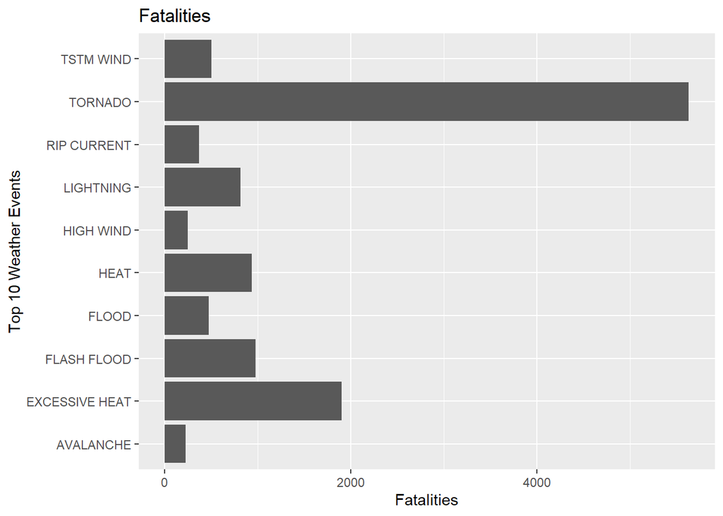

```r
ggplot(data=sh10f, aes(x=EVTYPE, y=f_sum)) + geom_bar(stat="identity") + coord_flip() +ylab("Fatalities") + xlab("Top 10 Weather Events") + ggtitle("Fatalities")
```

When looking at injuries, toronados accounted for significantly more injuries than the rest of the events over the sampled period.

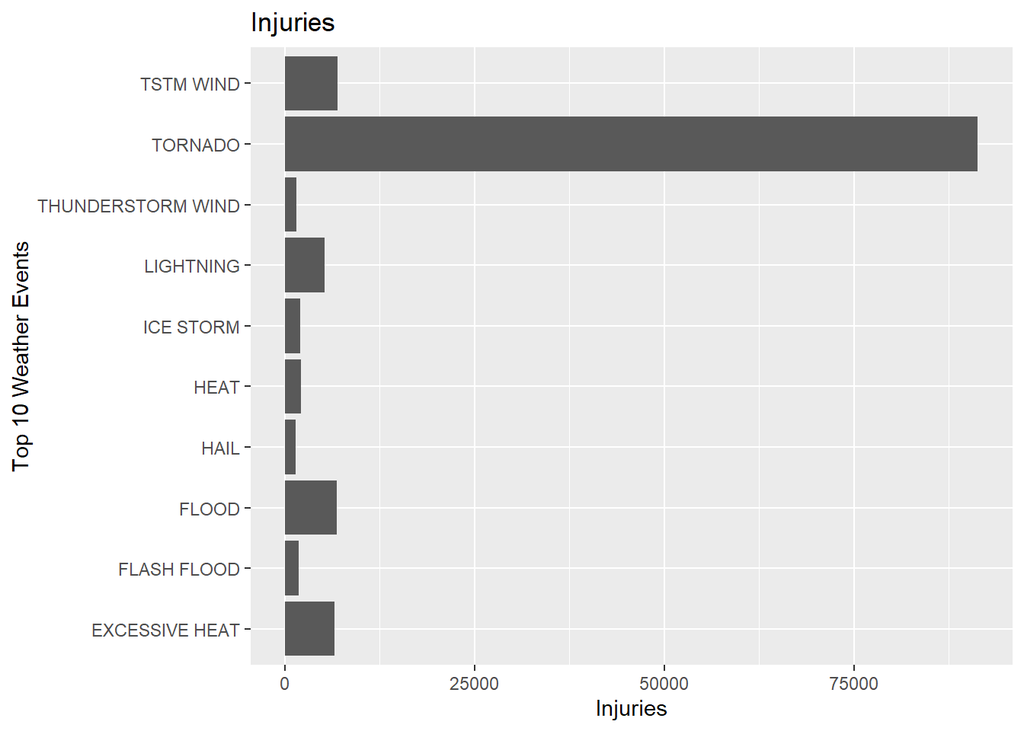

```r
ggplot(data=sh10, aes(x=EVTYPE, y=i_sum)) + geom_bar(stat="identity") + coord_flip() +ylab("Injuries") + xlab("Top 10 Weather Events") + ggtitle("Injuries")
```

Focusing on economic damage, toronadoes, thunderstorm wind and flash flooding were the three largest contirbutors to weather related property damage for the sampled period.

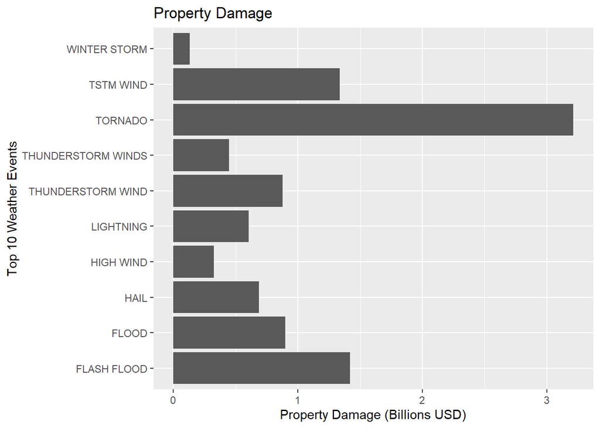

```r
ggplot(data=sep10, aes(x=EVTYPE, y=p_sum)) + geom_bar(stat="identity") + coord_flip() +ylab("Property Damage (Billions USD)") + xlab("Top 10 Weather Events") + ggtitle("Property Damage")
```